# Confidence Intervals

# The Goal

You’ve asked how to build this type of visualisation:

```r
library(plotly)
x <- rnorm(100)
y <-  + .7*x + rnorm(100)
f1 <- as.factor(c(rep("A",50),rep("B",50)))
f2 <- as.factor(rep(c(rep("C",25),rep("D",25)),2))
df <- data.frame(cbind(x,y))
df$f1 <- f1
df$f2 <- f2
{ggplot(df,aes(x=x,y=y)) +
    geom_point() +
    facet_grid(f1~f2) +
    stat_smooth(method="lm") }%>%
  ggplotly()
```

[interactive chart not shown]

But first we need to be able to build this chart:

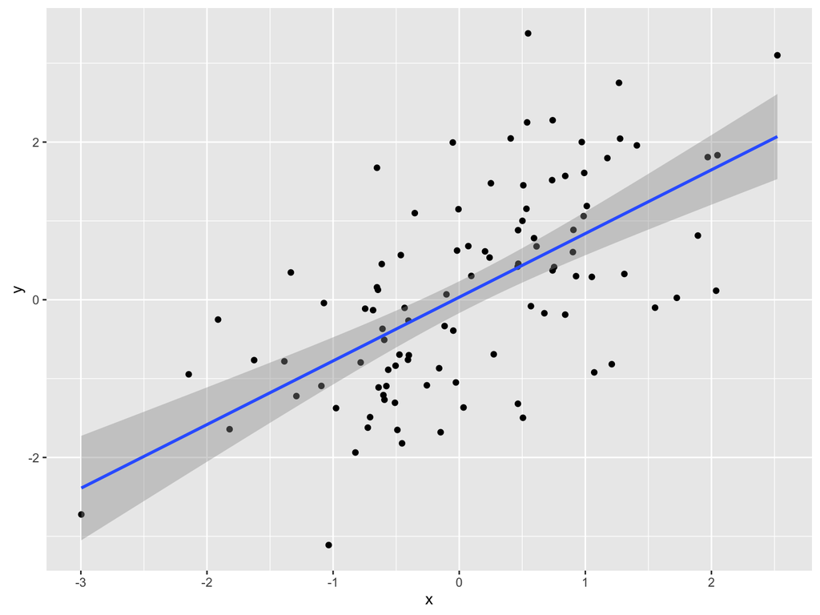

```r
library(ggplot2)
x <- rnorm(100)
y <-  + .7*x + rnorm(100)
f1 <- as.factor(c(rep("A",50),rep("B",50)))
f2 <- as.factor(rep(c(rep("C",25),rep("D",25)),2))
df <- data.frame(cbind(x,y))
df$f1 <- f1
df$f2 <- f2
ggplot(df,aes(x=x,y=y)) +
    geom_point() +
    stat_smooth(method="lm")
```

# Tools/Techniques we need

- Importing Data
- Setting Factors
- ggplot2
- facets in ggplot2
- Making ggplot2 interactive with ggplotly

# Importing Data

The data for this example is stored within an .xlsx file, which can be imported directly using the `xlsx` library. However:

- The `xlsx` library depends on a specific version of Java being installed and set as an appropriate PATH variable.
- It is tremendously slow.

```r
library(xlsx)
confidence_data <- read.xlsx2("data/confidence-data.xlsx", sheetIndex = 1)
```

- It’s also quite dumb

```r
str(confidence_data)
```

```
## 'data.frame':    100 obs. of  4 variables:
##  $ metric1 : Factor w/ 100 levels "-0.011030299097902947",..: 84 76 42 60 91 49 93 68 56 14 ...
##  $ metric2 : Factor w/ 100 levels "-0.007906297621546154",..: 21 9 13 43 88 70 22 78 87 41 ...
##  $ category: Factor w/ 2 levels "Rural","Urban": 1 1 1 1 1 1 1 1 1 1 ...
##  $ country : Factor w/ 2 levels "India","Vietnam": 1 1 1 1 1 1 1 1 1 1 ...
```

# xlsx_convert_import

My personal recommendation is to import as .xlsx and export to csv, it makes data processing much simpler. This utility function provides a simple way to achieve this:

```r
xlsx_convert_import <- function(inputFile = NA, outputFile = NA){
  if(file.exists(outputFile)){
    imported_data <<- read_csv(outputFile)
  } else {
    library(xlsx)
    xlsx_import <- read.xlsx2(inputFile, sheetIndex = 1)
    write.csv(xlsx_import, file = outputFile, row.names = FALSE)
    imported_data <<- read_csv(outputFile)
  }
}
```

Note that the function uses the `read_csv` function from `readr`:

```r
library(readr)
confidence_data <- xlsx_convert_import(inputFile = "data/confidence-data.xlsx", outputFile = "data/confidence-data.csv")
str(confidence_data)
```

```
## Classes 'tbl_df', 'tbl' and 'data.frame':    100 obs. of  4 variables:
##  $ metric1 : num  0.929 0.786 -1.524 0.278 1.186 ...
##  $ metric2 : num  -0.444 -0.174 -0.212 -1.649 1.314 ...
##  $ category: chr  "Rural" "Rural" "Rural" "Rural" ...
##  $ country : chr  "India" "India" "India" "India" ...
##  - attr(*, "spec")=List of 2
##   ..$ cols   :List of 4
##   .. ..$ metric1 : list()
##   .. .. ..- attr(*, "class")= chr  "collector_double" "collector"
##   .. ..$ metric2 : list()
##   .. .. ..- attr(*, "class")= chr  "collector_double" "collector"
##   .. ..$ category: list()
##   .. .. ..- attr(*, "class")= chr  "collector_character" "collector"
##   .. ..$ country : list()
##   .. .. ..- attr(*, "class")= chr  "collector_character" "collector"
##   ..$ default: list()
##   .. ..- attr(*, "class")= chr  "collector_guess" "collector"
##   ..- attr(*, "class")= chr "col_spec"
```

# ggplot2

The `ggplot2` provides us a complete “grammar of graphics”, a consistent methodology for building and adding to charts (as well as maps and network diagrams!).

Documentation for `ggplot2` is available here http://docs.ggplot2.org/current/ and there is also a great cheat sheet available under Help in the menubar.

# ggplot and aes

The workhorses of a `ggplot2` plot are as follows:

- `ggplot(data = df, ...)` initiates a ggplot object with `df` as the `data` to be used within the object.
- `aes` specifies the “aesthetic mappings” for how variables in the `data` are mapped to visual properties of the object

We can therefore create an empty chart as follows:

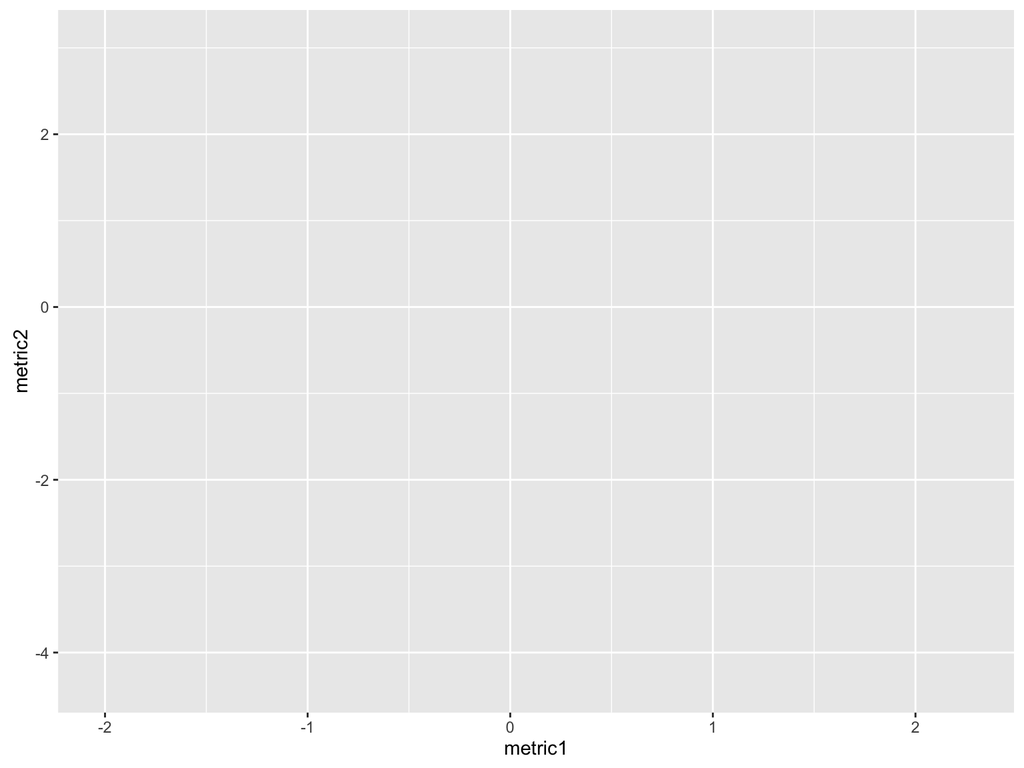

```r
ggplot(confidence_data ,aes(x = metric1, y = metric2))
```

# Adding layers

To include additional visual elements to the chart, add “layers” with the `+` operator:

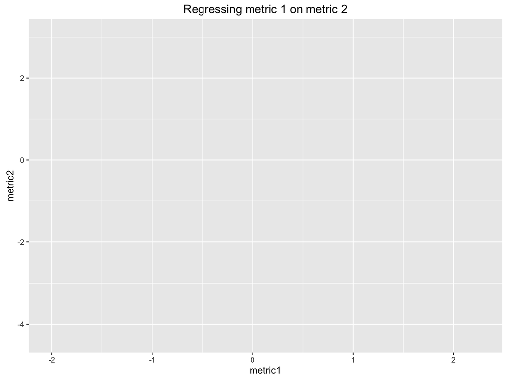

```r
ggplot(confidence_data ,aes(x = metric1, y = metric2)) +
  ggtitle("Regressing metric 1 on metric 2")
```

Often users choose to make intermediatry assignments in building their charts:

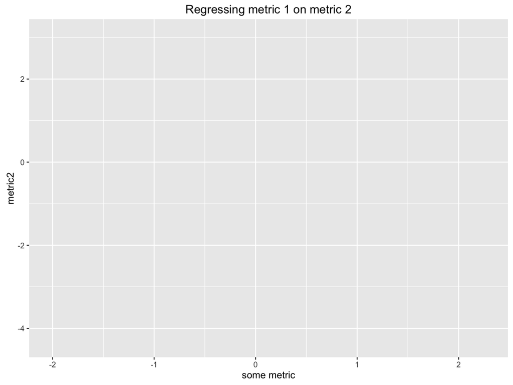

```r
regress_chart <- ggplot(confidence_data ,aes(x = metric1, y = metric2)) +
  ggtitle("Regressing metric 1 on metric 2")


regress_chart + xlab("some metric")
```

# geoms

Geoms are used to add visual features to a chart, using the `aes` mappings between data variables and the chart’s coordinate system:

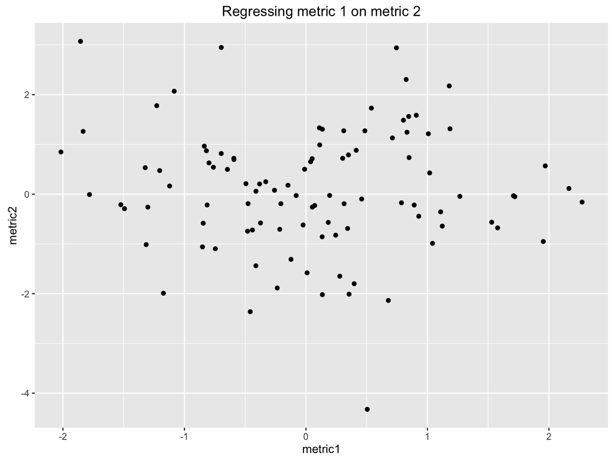

```r
regress_chart <- ggplot(confidence_data ,aes(x = metric1, y = metric2)) +
  ggtitle("Regressing metric 1 on metric 2")

regress_chart + geom_point()
```

Regression and associated confidence levels can easily be plotted together using the `stat_smooth` function:

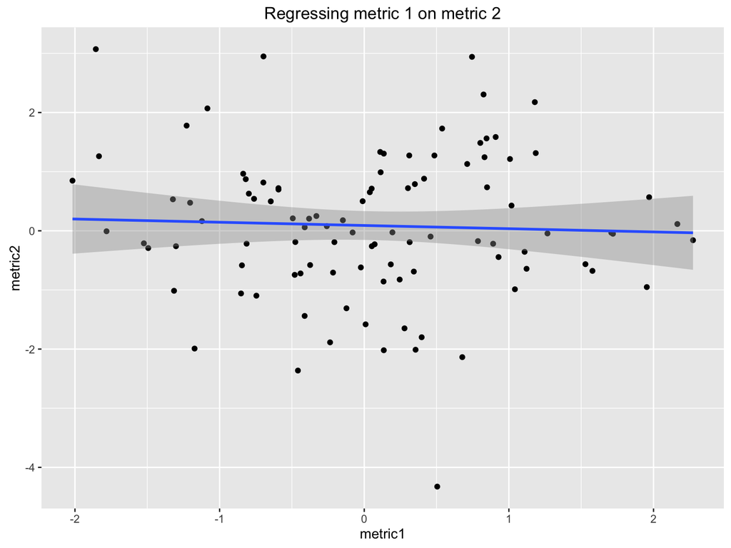

```r
regress_chart + geom_point() + stat_smooth(method="lm")
```

# Where is that model?

The models used by `stat_smooth` are accessible directly using `loess` (the automatically chosen fitting method for small datasets)

```r
confidence_loess_model <- loess(metric2 ~ metric1, confidence_data)
```

Models have many properties, as with most objects these can be listed with `names`

```r
names(confidence_loess_model)
```

```
##  [1] "n"         "fitted"    "residuals" "enp"       "s"
##  [6] "one.delta" "two.delta" "trace.hat" "divisor"   "robust"
## [11] "pars"      "kd"        "call"      "terms"     "xnames"
## [16] "x"         "y"         "weights"
```

What about real models? loess is for exploring relations

# lm

All models use the same syntax, so to compute a linear model use:

```r
confidence_lm_model <- lm(metric2 ~ metric1, confidence_data)
```

Frustratingly, the properties of the model that you might assume to live in the object aren’t there! Where is the RSquared?

```r
names(confidence_lm_model)
```

```
##  [1] "coefficients"  "residuals"     "effects"       "rank"
##  [5] "fitted.values" "assign"        "qr"            "df.residual"
##  [9] "xlevels"       "call"          "terms"         "model"
```

To generate the R squared value, and other useful properties, you must use `summary` and extract from that object

```r
lm_model_summary <- summary(confidence_lm_model)
lm_model_summary$adj.r.squared
```

```
## [1] -0.008412414
```

# Back to ggplot and plotly

The `plotly` library allows us to convert “simple” `ggplot` objects directly into interactive charts:

```r
library(plotly)
regress_chart <- ggplot(confidence_data ,aes(x = metric1, y = metric2)) +
  ggtitle("Regressing metric 1 on metric 2")

ggplotly(regress_chart + geom_point() + stat_smooth(method="lm"))
```

[interactive chart not shown]

# Faceting charts

The dataset we’re looking at has a number of different facets, it’s useful to be able to split our chart by these.

In order to do that, we need to provide `ggplot` with a `factor` variable:

```r
confidence_data$country <- as.factor(confidence_data$country)
confidence_data$category <- as.factor(confidence_data$category)
```

`facet_grid` allows a chart to be split according to a factor(s):

- `facet_grid(. ~country)` will facet only on country by column

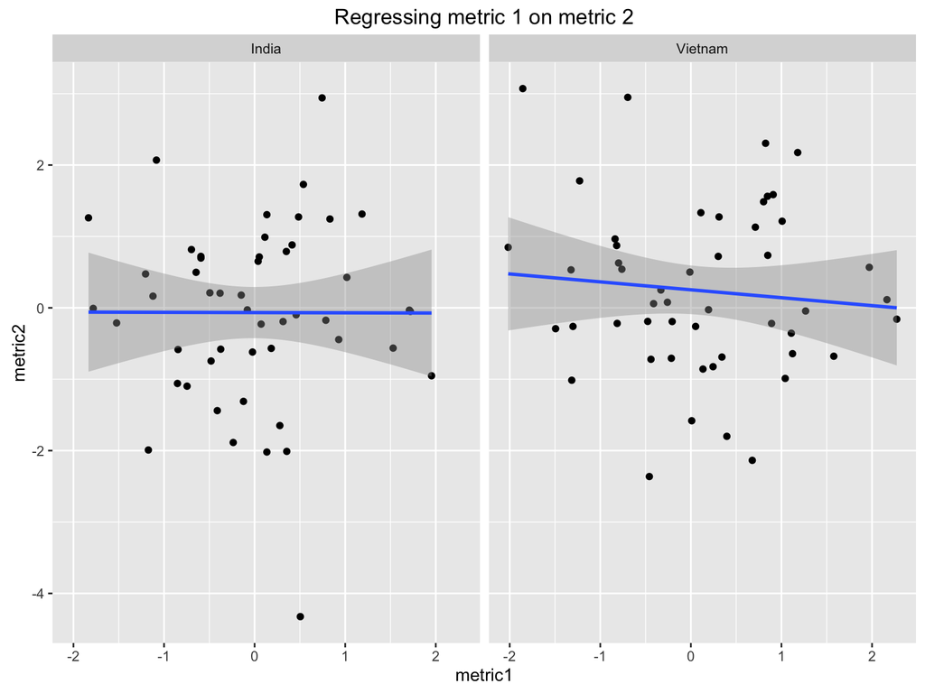

```r
regress_chart + facet_grid(. ~country) + geom_point() + stat_smooth(method="lm")
```

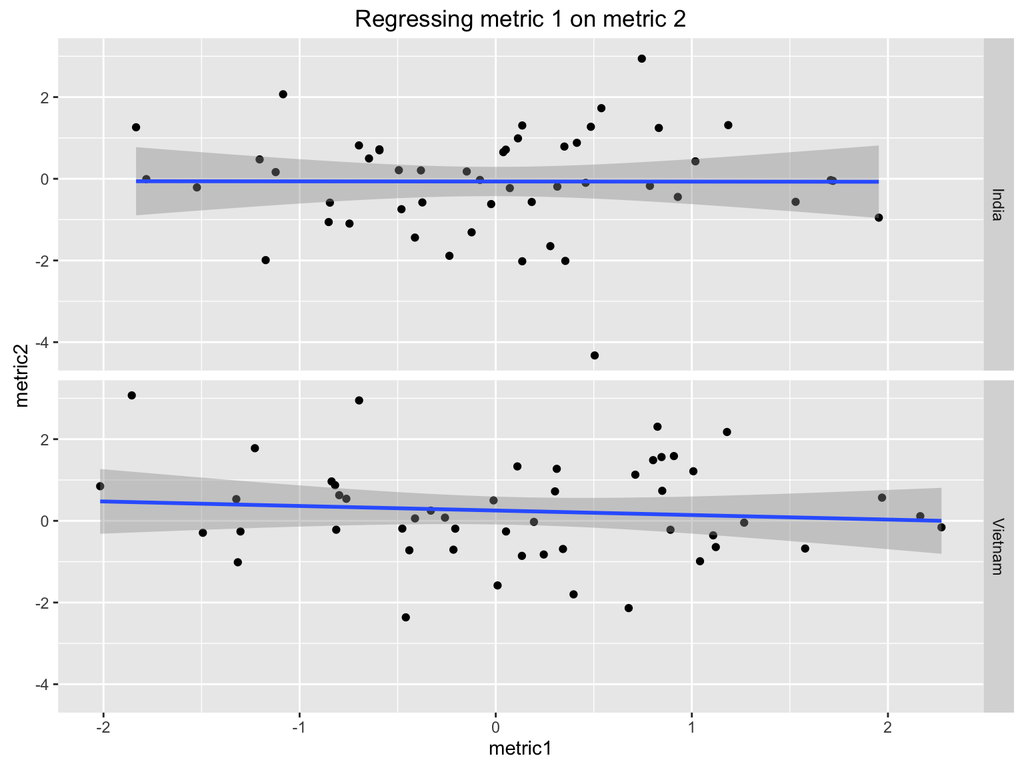

```r
regress_chart + facet_grid(country ~ .) + geom_point() + stat_smooth(method="lm")
```

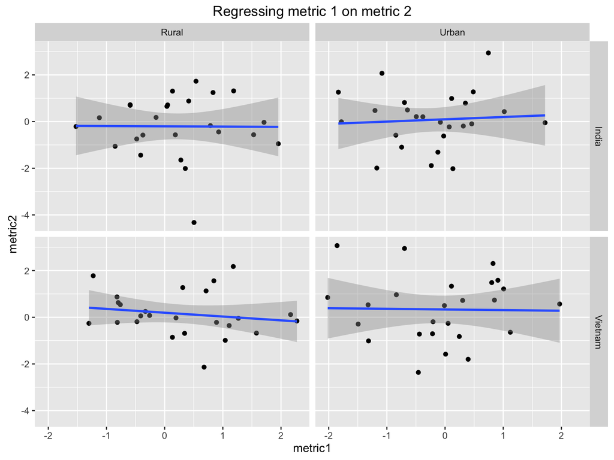

```r
regress_chart + facet_grid(country ~ category) + geom_point() + stat_smooth(method="lm")
```

- `ggplotly` will happily gobble up all of these

```r
ggplotly(regress_chart + facet_grid(country ~ category) + geom_point() + stat_smooth(method="lm"))
```

[interactive chart not shown]